# LLN and CLT

Jing Fang and Shihui Ma

# Overview

# Overview

- This lecture illustrates two of the most important theorems of probability and statistics: The law of large numbers (LLN) and the central limit theorem (CLT)
- These beautiful theorems lie behind many of the most fundamental results in econometrics and quantitative economic modeling
- The lecture is based around simulations that show the LLN and CLT in action
- We also demonstrate how the LLN and CLT break down when the assumptions they are based on do not hold

# Overview

- In addition, we examine several useful extensions of the classical theorems, such as
  - The delta method, for smooth functions of random variables
  - The multivariate case
- Some of these extensions are presented as exercises

# Relationships

# Relationships

- The CLT refines the LLN
- The LLN gives conditions under which sample moments converge to population moments as sample size increases
- The CLT provides information about the rate at which sample moments converge to population moments as sample size increases

# LLN

# The Classical LLN

- The classical law of large numbers concerns independent and identically distributed (IID) random variables
- Here is the strongest version of the classical LLN, known as *Kolmogorov’s strong law*
- Let $X_1,...,X_n$ be independent and identically distributed scalar random variables, with common distribution $F$
- When it exists, let $\mu$ denote the common mean of this sample:
  $$\mu=\mathbb{E}X=\int xF(dx)$$

# The Classical LLN

- In addition, let
  $$\bar{X}_n=\frac{1}{n}\sum_{i=1}^n X_i$$
- Kolmogorov’s strong law states that, if $\mathbb{E}|X|$ is finite, then
  $$\mathbb{P}\{\bar{X}_n\to\mu \text{ as }n\to\infty\}=1$$
- What does this last expression mean?

# The Classical LLN

- Let’s think about it from a simulation perspective, imagining for a moment that our computer can generate perfect random samples (which of course it can’t)
- Let’s also imagine that we can generate infinite sequences, so that the statement $\bar{X}_n\to\mu$ can be evaluated
- In this setting, the equation should be interpreted as meaning that the probability of the computer producing a sequence where $\bar{X}_n\to\mu$ fails to occur is zero

# Proof

- The proof of Kolmogorov’s strong law is nontrivial
- On the other hand, we can prove a weaker version of the LLN very easily and still get most of the intuition
- The version we prove is as follows: If $X_1,...,X_n$ is IID with $\mathbb{E}X^2_i<\infty$, then, for any $\varepsilon>0$, we have
  $$\mathbb{P}\{|\bar{X}_n-\mu|\geq\varepsilon\}\to 0 \text{ as } n\to\infty$$
- (This version is weaker because we claim only convergence in probability rather than almost sure convergence, and assume a finite second moment)

# Proof

- To see that this is so, fix $\varepsilon>0$, and let $\sigma^2$ be the variance of each $X_i$
- Recall the Chebyshev inequality, which tells us that
  $$\mathbb{P}\{|\bar{X}_n-\mu|\geq\varepsilon\}\leq\frac{\mathbb{E}[(\bar{X}_n-\mu)^2]}{\varepsilon^2}$$

# Proof

- Now ovserve that
  $$\begin{array}[lll]
  \mathbb{E}[(\bar{X}_n-\mu)^2] & = & \mathbb{E}\{[\frac{1}{n}\sum_{i=1}^n(X_i-\mu)]^2\} \\
  & = & \frac{1}{n^2}\sum_{i=1}^n\sum_{j=1}^n\mathbb{E}(X_i-\mu)(X_j-\mu) \\
  & = & \frac{1}{n^2}\sum_{i=1}^n\mathbb{E}(X_i-\mu)^2 \\
  & = & \frac{\sigma^2}{n}
  \end{array}$$

# Proof

- Here the crucial step is at the third equality, which follows from independence
- Independence means that if $i\neq j$, then the covariance term $\mathbb{E}(X_i−\mu)(X_j−\mu)$ drops out
- As a result, $n^2−n$ terms vanish, leading us to a final expression that goes to zero in $n$
- Combining our last result with Chebyshev inequality, we come to the estimate
  $$\mathbb{P}\{|\bar{X}_n-\mu|\geq\varepsilon\}\leq\frac{\sigma^2}{n\varepsilon^2}$$

# Proof

- The claim is now clear
- Of course, if the sequence $X_1,...,X_n$ is correlated, then the cross-product terms $\mathbb{E}(X_i−\mu)(X_j−\mu)$ are not necessarily zero
- While this doesn’t mean that the same line of argument is impossible, it does mean that if we want a similar result then the covariances should be “almost zero” for “most” of these terms

# Proof

- In a long sequence, this would be true if, for example, $\mathbb{E}(X_i−\mu)(X_j−\mu)$ approached zero when the difference between $i$ and $j$ became large
- In other words, the LLN can still work if the sequence $X_1,...,X_n$ has a kind of “asymptotic independence”, in the sense that correlation falls to zero as variables become further apart in the sequence
- This idea is very important in time series analysis, and we’ll come across it again soon enough

# Illustration

- Let’s now illustrate the classical IID law of large numbers using simulation
- In particular, we aim to generate some sequences of IID random variables and plot the evolution of $\bar{X}_n$ as $n$ increases
- Below is a figure that does just this
- It shows IID observations from three different distributions and plots $\bar{X}_n$ against $n$ in each case

# Illustration

- The dots represent the underlying observations $X_i$ for $i=1,...,100$
- In each of the three cases, convergence of $\bar{X}_n$ to $\mu$ occurs as predicted

# Illustration

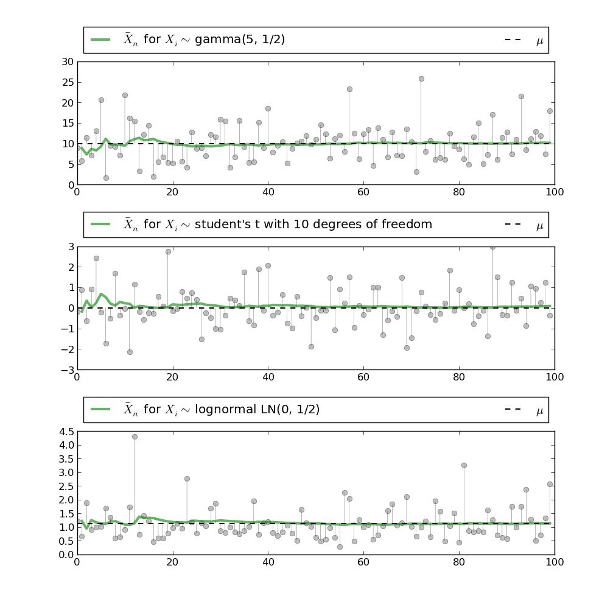

# Illustration

- The figure was produced by illustrates_lln.py, which is shown below
- The three distributions are chosen at random

# Illustration

```python
"""
Visual illustration of the law of large numbers.
"""
import random
import numpy as np
from scipy.stats import t, beta, lognorm, expon, gamma, poisson
import matplotlib.pyplot as plt
n = 100
# == Arbitrary collection of distributions == #
distributions = {"student's t with 10 degrees of freedom": t(10),
                 "beta(2, 2)": beta(2, 2),
                 "lognormal LN(0, 1/2)": lognorm(0.5),
                 "gamma(5, 1/2)": gamma(5, scale=2),
                 "poisson(4)": poisson(4),
                 "exponential with lambda = 1": expon(1)}
# == Create a figure and some axes == #
num_plots = 3
fig, axes = plt.subplots(num_plots, 1, figsize=(10, 10))
# == Set some plotting parameters to improve layout == #
bbox = (0., 1.02, 1., .102)
legend_args = {'ncol': 2,
               'bbox_to_anchor': bbox,
               'loc': 3,
               'mode': 'expand'}
plt.subplots_adjust(hspace=0.5)
for ax in axes:
    # == Choose a randomly selected distribution == #
    name = random.choice(list(distributions.keys()))
    distribution = distributions.pop(name)
    # == Generate n draws from the distribution == #
    data = distribution.rvs(n)
    # == Compute sample mean at each n == #
    sample_mean = np.empty(n)
    for i in range(n):
        sample_mean[i] = np.mean(data[:i+1])
    # == Plot == #
    ax.plot(list(range(n)), data, 'o', color='grey', alpha=0.5)
    axlabel = r'$\bar X_n$' + ' for ' + r'$X_i \sim$' + ' ' + name
    ax.plot(list(range(n)), sample_mean, 'g-', lw=3, alpha=0.6, label=axlabel)
    m = distribution.mean()
    ax.plot(list(range(n)), [m] * n, 'k--', lw=1.5, label=r'$\mu$')
    ax.vlines(list(range(n)), m, data, lw=0.2)
    ax.legend(**legend_args)
plt.show()
```

# Infinite Mean

- What happens if the condition $\mathbb{E}|X|<\infty$ in the statement of the LLN is not satisfied?
- This might be the case if the underlying distribution is heavy tailed — the best known example is the Cauchy distribution, which has density
  $$f(x)=\frac{1}{\pi(1+x^2)}\:(x\in\mathbb{R})$$
- The next figure shows 100 independent draws from this distribution

# Infinite Mean

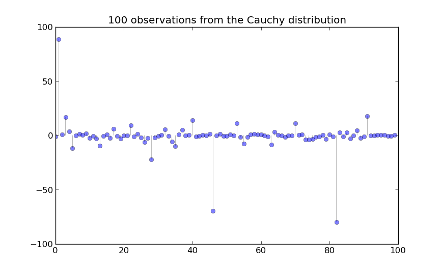

# Infinite Mean

- Notice how extreme observations are far more prevalent here than the previous figure
- Let’s now have a look at the behavior of the sample mean

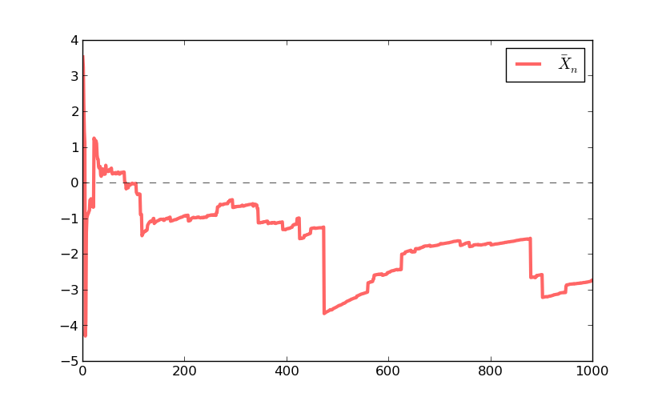

# Infinite Mean

- Here we’ve increased $n$ to 1000, but the sequence still shows no sign of converging
- Will convergence become visible if we take $n$ even larger?
- The answer is no
- To see this, recall that the characteristic function of the Cauchy distribution is
  $$\phi(t)=\mathbb{E}e^{itX}=\int e^{itx}f(x)dx=e^{-|t|}$$

# Infinite Mean

- Using independence, the characteristic function of the sample mean becomes
  $$\begin{array}[lll]
  \mathbb{E}e^{it\bar{X}_n} & = & \mathbb{E}\exp\{i\frac{t}{n}\sum_{j=1}^n X_j\} \\
  & = & \mathbb{E}\prod_{j=1}^n\exp\{i\frac{t}{n}X_j\} \\
  & = & \prod_{j=1}^n\mathbb{E}\exp\{i\frac{t}{n}X_j\}=[\phi(t/n)]^n
  \end{array}$$
- In view of original characteristic function, this is just $e^{−|t|}$

# Infinite Mean

- Thus, in the case of the Cauchy distribution, the sample mean itself has the very same Cauchy distribution, regardless of $n$
- In particular, the sequence $\bar{X}_n$ does not converge to a point

# CLT

# Statement of the Theorem

- The central limit theorem is one of the most remarkable results in all of mathematics
- In the classical IID setting, it tells us the following:

# Statement of the Theorem

- If the sequence $X_1,...,X_n$ is IID, with common mean $\mu$ and common variance $\sigma^2\in(0,\infty)$, then
  $$\sqrt{n}(\bar{X}_n−\mu)\overset{d}{\to}N(0,\sigma^2)\text{ as }n→\infty$$
- Here $\overset{d}{\to}N(0,\sigma^2)$ indicates convergence in distribution to a centered (i.e, zero mean) normal with standard deviation $\sigma$

# Intuition

- The striking implication of the CLT is that for any distribution with finite second moment, the simple operation of adding independent copies always leads to a Gaussian curve
- A relatively simple proof of the central limit theorem can be obtained by working with characteristic functions
- The proof is elegant but almost anticlimactic, and it provides surprisingly little intuition

# Intuition

- In fact all of the proofs of the CLT that we know are similar in this respect
- Why does adding independent copies produce a bell-shaped distribution?
- Part of the answer can be obtained by investigating addition of independent Bernoulli random variables

# Intuition

- In particular, let $X_i$ be binary, with $\mathbb{P}\{X_i=0\}=\mathbb{P}\{X_i=1\}=0.5$, and let $X_1,...,X_n$ be independent
- Think of $X_i=1$ as a “success”, so that $Y_n=\sum^n_{i=1}X_i$ is the number of successes in $n$ trials
- The next figure plots the probability mass function of $Y_n$ for $n=1,2,4,8$

# Intuition

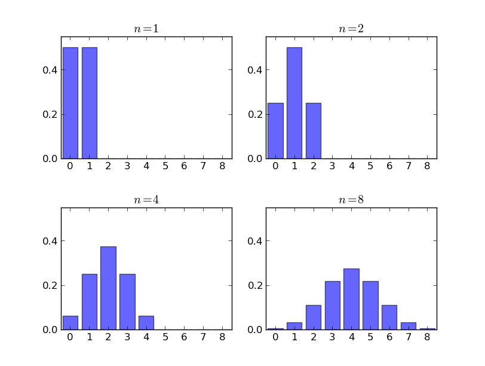

# Intuition

- When $n=1$, the distribution is flat — one success or no successes have the same probability
- When $n=2$ we can either have 0, 1 or 2 successes
- Notice the peak in probability mass at the mid-point $k=1$
- The reason is that there are more ways to get 1 success (“fail then succeed” or “succeed then fail”) than to get zero or two successes

# Intuition

- Moreover, the two trials are independent, so the outcomes “fail then succeed” and “succeed then fail” are just as likely as the outcomes “fail then fail” and “succeed then succeed”
- Here, already we have the essence of the CLT: addition under independence leads probability mass to pile up in the middle and thin out at the tails

# Intuition

- For $n=4$ and $n=8$ we again get a peak at the “middle” value (halfway between the minimum and the maximum possible value)
- The intuition is the same — there are simply more ways to get these middle outcomes
- If we continue, the bell-shaped curve becomes ever more pronounced
- We are witnessing the binomial approximation of the normal distribution

# Simulation 1

- Since the CLT seems almost magical, running simulations that verify its implications is one good way to build intuition
- To this end, we now perform the following simulation
  1. Choose an arbitrary distribution $F$ for the underlying observations $X_i$
  2. Generate independent draws of $Y_n=\sqrt{n}(\bar{X}_n−\mu)$
  3. Use these draws to compute some measure of their distribution — such as a histogram
  4. Compare the latter to $N(0,\sigma^2)$

# Simulation 1

- Here’s some code that does exactly this for the exponential distribution $F(x)=1−e^{−\lambda x}$
- Please experiment with other choices of F, but remember that, to conform with the conditions of the CLT, the distribution must have finite second moment

# Simulation 1

```python
import numpy as np
from scipy.stats import expon, norm
import matplotlib.pyplot as plt
from matplotlib import rc
# == Set parameters == #
n = 250     # Choice of n
k = 100000  # Number of draws of Y_n
distribution = expon(2)  # Exponential distribution, lambda = 1/2
mu, s = distribution.mean(), distribution.std()
# == Draw underlying RVs. Each row contains a draw of X_1,..,X_n == #
data = distribution.rvs((k, n))
# == Compute mean of each row, producing k draws of \bar X_n == #
sample_means = data.mean(axis=1)
# == Generate observations of Y_n == #
Y = np.sqrt(n) * (sample_means - mu)
# == Plot == #
fig, ax = plt.subplots()
xmin, xmax = -3 * s, 3 * s
ax.set_xlim(xmin, xmax)
ax.hist(Y, bins=60, alpha=0.5, normed=True)
xgrid = np.linspace(xmin, xmax, 200)
ax.plot(xgrid, norm.pdf(xgrid, scale=s), 'k-', lw=2, label=r'$N(0, \sigma^2)$')
ax.legend()
plt.show()
```

[output not shown]

# Simulation 1

# Simulation 2

- Our next simulation is somewhat like the first, except that we aim to track the distribution of $Y_n=\sqrt{n}(\bar{X}_n−\mu)$ as $n$ increases
- In the simulation we’ll be working with random variables having $\mu=0$
- Thus, when $n=1$, we have $Y_1=X_1$, so the first distribution is just the distribution of the underlying random variable
- For $n=2$, the distribution of $Y_2$ is that of $(X1+X2)/\sqrt{2}$, and so on

# Simulation 2

- What we expect is that, regardless of the distribution of the underlying random variable, the distribution of $Y_n$ will smooth out into a bell shaped curve
- The next figure shows this process for $X_i\sim f$, where $f$ was specified as the convex combination of three different beta densities
- In the figure, the closest density is that of $Y_1$, while the furthest is that of $Y_5$

# Simulation 2

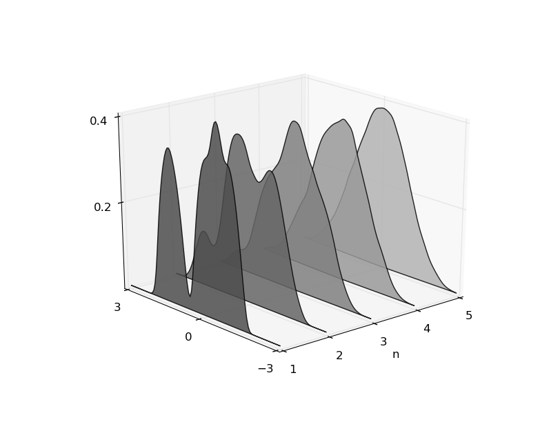

# The Multivariate Case

- The law of large numbers and central limit theorem work just as nicely in multidimensional settings
- To state the results, let’s recall some elementary facts about random vectors
- A random vector $\mathbf{X}$ is just a sequence of $k$ random variables $(\mathbf{X_1},...,\mathbf{X_k})$
- Each realization of $\mathbf{X}$ is an element of $\mathbb{R}^k$

# The Multivariate Case

- A collection of random vectors $(\mathbf{X_1},...,\mathbf{X_n})$ is called independent if, given any $n$ vectors $(\mathbf{x_1},...,\mathbf{x_n})$ in $\mathbb{R}^k$, we have
  $$\mathbb{P}\{\mathbf{X_1}\leq\mathbf{x_1},...,\mathbf{X_n}\leq\mathbf{x_n}\}=\mathbb{P}\{\mathbf{X_1}\leq\mathbf{x_1}\}\times...\times\mathbb{P}\{\mathbf{X_n}\leq\mathbf{x_n}\}$$
- The vector inequality $\mathbf{X}\leq\mathbf{x}$ means that $X_j\leq x_j$ for $j=1,...,k$

# The Multivariate Case

- Let $\mu_j=\mathbb{E}[X_j]$ for all $j=1,...,k$
- The expectation $\mathbb{E}[\mathbf{X}]$ of $\mathbf{X}$ is defined to be the vector of expectations:
  $$\mathbb{E}[\mathbf{X}]=\begin{pmatrix}
  \mathbb{E}[X_1] \
  \mathbb{E}[X_2] \
  \vdots \
  \mathbb{E}[X_k]
  \end{pmatrix}=\begin{pmatrix}
  \mu_1 \
  \mu_2 \
  \vdots \
  \mu_k \
  \end{pmatrix}=\mathbf{\mu}$$
- The *variance-covariance matrix* of random vector $\mathbf{X}$ is defined as
  $$Var[\mathbf{X}]=\mathbb{E}[(\mathbf{X-\mu})(\mathbf{X-\mu})']$$

# The Multivariate Case

- Expanding this out, we get
  $$Var[\mathbf{X}]=\begin{pmatrix}
  \mathbb{E}[(X_1-\mu_1)(X_1-\mu_1)] & ... & \mathbb{E}[(X_1-\mu_1)(X_k-\mu_k)] \\
  \mathbb{E}[(X_2-\mu_2)(X_1-\mu_1)] & ... & \mathbb{E}[(X_2-\mu_2)(X_k-\mu_k)] \\
  \vdots & \vdots & \vdots \\
  \mathbb{E}[(X_k-\mu_k)(X_1-\mu_1)] & ... & \mathbb{E}[(X_k-\mu_k)(X_k-\mu_k)]
  \end{pmatrix}$$
- The $j,k$-th term is the scalar covariance between $X_j$ and $X_k$
- With this notation we can proceed to the multivariate LLN and CLT

# The Multivariate Case

- Let $(\mathbf{X_1},...,\mathbf{X_n})$ be a sequence of independent and identically distributed random vectors, each one taking values in $\mathbb{R}^k$
- Let $\mathbf{\mu}$ be the vector $\mathbb{E}[\mathbf{X_i}]$, and let $\mathbf{\Sigma}$ be the variance-covariance matrix of $\mathbf{X_i}$
- Interpreting vector addition and scalar multiplication in the usual way (i.e., pointwise), let
  $$\mathbf{\bar{X}_n}=\frac{1}{n}\sum_{i=1}^n\mathbf{X_i}$$

# The Multivariate Case

- In this setting, the LLN tells us that
  $$\mathbb{P}\{\mathbf{\bar{X}_n}\to\mathbf{\mu}\text{ as }n\to\infty\}=1$$
- Here $\mathbf{\bar{X}_n}\to\mathbf{\mu}$ means that $\left\|\mathbf{\bar{X}_n}\to\mathbf{\mu}\right\|\to 0$, where $\left\|⋅\right\|$ is the standard Euclidean norm
- The CLT tells us that, provided $\mathbf{\Sigma}$ is finite,
  $$\sqrt{n}(\mathbf{\bar{X}_n-\mu}) \overset{d}{\to}N(\mathbf{0,\Sigma})\text{ as }n\to\infty$$

# Exercises

# Exercises 1

- One very useful consequence of the central limit theorem is as follows
- Assume the conditions of the CLT as stated above
- If $g:\mathbb{R}\to\mathbb{R}$ is differentiable at $\mu$ and $g'(\mu)\neq 0$, then
  $$\sqrt{n}\{g(\bar{X}_n)−g(\mu)\} \overset{d}{\to} N(0,g'(\mu)^2\sigma^2) \text{ as }n\to\infty$$
- This theorem is used frequently in statistics to obtain the asymptotic distribution of estimators — many of which can be expressed as functions of sample means

# Exercises 1

- These kinds of results are often said to use the “delta method”
- The proof is based on a Taylor expansion of $g$ around the point $\mu$

# Exercises 1

- Taking the result as given, let the distribution $F$ of each $X_i$ be uniform on $[0,\pi/2]$ and let $g(x)=\sin(x)$
- Derive the asymptotic distribution of $\sqrt{n}\{g(\bar{X}_n)−g(\mu)\}$ and illustrate convergence in the same spirit as the program discussed above
- What happens when you replace $[0,\pi/2]$ with $[0,\pi]$?
- What is the source of the problem?

# Exercises 2

- Here’s a result that’s often used in developing statistical tests, and is connected to the multivariate central limit theorem
- If you study econometric theory, you will see this result used again and again

# Exercises 2

- Assume the setting of the multivariate CLT discussed above, so that
  1. $(\mathbf{X_1},...,\mathbf{X_n})$ is a sequence of IID random vectors, each taking values in $\mathbb{R}^k$
  2. $\mathbf{\mu}=\mathbb{E}[\mathbf{X_i}]$, and $\mathbf{\Sigma}$ is the variance-covariance matrix of $\mathbf{X_i}$
  3. The convergence
     $$\sqrt{n}(\mathbf{\bar{X}_n−\mu}) \overset{d}{\to} N(\mathbf{0,\Sigma})$$
     is valid

# Exercises 2

- In a statistical setting, one often wants the right hand side to be **standard** normal, so that confidence intervals are easily computed
- This normalization can be achieved on the basis of three observations
- First, if $\mathbf{X}$ is a random vector in $\mathbb{R}^k$ and $\mathbf{A}$ is constant and $k\times k$, then
  $$Var[\mathbf{AX}]=\mathbf{A}Var[\mathbf{X}]\mathbf{A'}$$

# Exercises 2

- Second, by the continuous mapping theorem, if $\mathbf{Z_n} \overset{d}{\to} \mathbf{Z}$ in $\mathbb{R}^k$ and $\mathbf{A}$ is constant and $k\times k$, then
  $$\mathbf{AZ_n} \overset{d}{\to} \mathbf{AZ}$$
- Third, if $\mathbf{S}$ is a $k\times k$ symmetric positive definite matrix, then there exists a symmetric positive definite matrix $\mathbf{Q}$, called the inverse [square root](https://en.wikipedia.org/wiki/Square_root_of_a_matrix) of $\mathbf{S}$, such that
  $$\mathbf{QSQ'=I}$$
- Here $\mathbf{I}$ is the $k\times k$ identity matrix

# Exercises 2

- Putting these things together, your first exercise is to show that if $\mathbf{Q}$ is the inverse square root of $\mathbf{\Sigma}$, then
  $$\mathbf{Z_n}=\sqrt{n}\mathbf{Q(\bar{X}_n-\mu)} \overset{d}{\to} \mathbf{Z\sim N(0,I)}$$
- Applying the continuous mapping theorem one more time tells us that
  $$\left\|\mathbf{Z_n}\right\|^2 \overset{d}{\to} \left\|\mathbf{Z}\right\|^2$$

# Exercises 2

- Given the distribution of $\mathbf{Z}$, we conclude that
  $$n\left\|\mathbf{Q(\bar{X}_n-\mu)}\right\|^2 \overset{d}{\to} \chi^2(k)$$
  where $\chi^2(k)$ is the chi-squared distribution with $k$ degrees of freedom
- (Recall that $k$ is the dimension of $\mathbf{X_i}$, the underlying random vectors)
- Your second exercise is to illustrate the convergence in above equation with a simulation

# Exercises 2

- In doing so, let
  $$\mathbf{X_i}=\begin{pmatrix}
  W_i \\
  U_i+W_i
  \end{pmatrix}$$
  where
  - each $W_i$ is an IID draw from the uniform distribution on [−1,1]
  - each $U_i$ is an IID draw from the uniform distribution on [−2,2]
  - $U_i$ and $W_i$ are independent of each other

# Exercises 2

- Hints:
  - `scipy.linalg.sqrtm(A)` computes the square root of A. You still need to invert it
  - You should be able to work out $\mathbf{\Sigma}$ from the proceding information